# Polysome proteomics

This document details the analysis of proteomics data acquired for comparisons of polysomes from CHLA10 cells.

## Setting up the environment

These are packages you will need for this notebook. For exact versions used, please refer to the session info at the bottom of this notebook.

```r
##########################################################################################
library('tidyverse')
library('RColorBrewer')
library('ggplot2')
library('DEqMS')
library('ggrepel')
```

I want to set a base directory that we can use as a link to the directory where we will do most of the work. I use two directories here because the Workspace is what is pushed to GitHub and contains scripts and plot files, but the Repository is where more of the big data is stored that does not get pushed.

```r
##########################################################################################
generalDatasets = 'C:/Users/chughes/Documents/bccrc/projectsRepository/generalDatasets'
baseWorkspace = 'C:/Users/chughes/Documents/bccrc/projectsWorkspace/sorensenLab/relatedToOthers'
baseRepository = 'C:/Users/chughes/Documents/bccrc/projectsRepository/sorensenLab/relatedToOthers'
#generalDatasets = 'C:/Users/chris/OneDrive/Documents/bccrc/projectsRepository/generalDatasets'
#baseWorkspace = 'C:/Users/chris/OneDrive/Documents/bccrc/projectsWorkspace/sorensenLab/relatedToYbx1'
#baseRepository = 'C:/Users/chris/OneDrive/Documents/bccrc/projectsRepository/sorensenLab/relatedToYbx1'
```

## Data processing

This is just a single batch, so we only have a single file we need to read in and process.

```r
##########################################################################################
psmId = read_tsv(paste(baseRepository, '/proteomics20210511_polysomeFractionsMs275Chla10/psm.tsv', sep = '')) %>%
  dplyr::select(Peptide, `Is Unique`, `Is Used`, `Protein ID`, Gene, `sample-01`:`sample-06`, `sample-09`:`sample-14`) %>%
  dplyr::rename(sequence = Peptide,
                unique = `Is Unique`,
                used = `Is Used`,
                accession = `Protein ID`,
                gene = Gene) %>%
  dplyr::filter(unique == TRUE, !grepl('CONT', accession), !is.na(gene), !grepl('-', gene)) %>%
  dplyr::rowwise(sequence, accession, gene) %>%
  dplyr::mutate(totalSignal = sum(c_across(`sample-01`:`sample-14`), na.rm = TRUE)) %>%
  dplyr::filter(totalSignal >= 100) %>%
  dplyr::select(-unique, -used) %>%
  dplyr::group_by(sequence, accession, gene) %>%
  dplyr::summarise(across(`sample-01`:`sample-14`, mean, na.rm = TRUE))
colnames(psmId)[4:15] = c('dmso_rep1','ms275_rep1','dmso_rep2','ms275_rep2','dmso_rep3','ms275_rep3',
                          'ars_rep1','combo_rep1','ars_rep2','combo_rep2','ars_rep3','combo_rep3')
```

Now we can process these data with DEqMS.

Our sample layout is:

- 126C - dmso_rep1
- 127N - ms275_rep1
- 127C - dmso_rep2
- 128N - ms275_rep2
- 128C - dmso_rep3
- 129N - ms275_rep3
- 129C - empty
- 130N - empty
- 130C - ars_rep1
- 131N - combo_rep1
- 131C - ars_rep2
- 132N - combo_rep2
- 132C - ars_rep3
- 133N - combo_rep3
- 133C - empty
- 134N - empty

We will also normalize the data to deal with any gross loading differences. We save both the non-normalized data here as well and check the normalization with a plot.

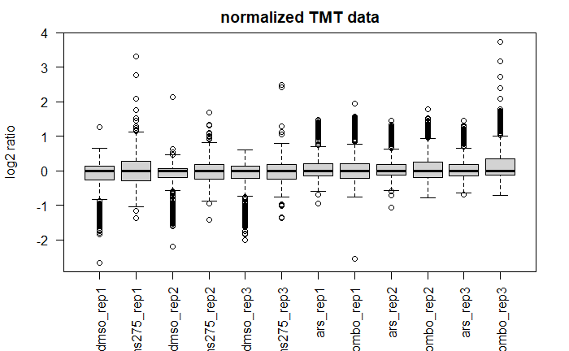

```r
##########################################################################################
quantInput = psmId[,c(1:2,4:15)]
saveRDS(quantInput, paste(baseRepository, '/proteomics20210511_polysomeFractionsMs275Chla10/dataset_peptideQuantDataPreDEqMS.rds', sep = ''))
quantInputLog = quantInput
quantInputLog[,3:14][quantInputLog[,3:14] == 0] = NA
quantInputLog[,3:14] = log2(quantInputLog[,3:14])
quantInputNormalized = medianSweeping(quantInputLog, group_col = 2)
boxplot(quantInputNormalized, las = 2, ylab = 'log2 ratio', main = 'normalized TMT data')
```

All of the data look tight. Good. Lets continue with the DEqMS analysis. We need to build our sample table.

```r
##########################################################################################
cond = as.factor(c('dmso','ms275','dmso','ms275','dmso','ms275','ars','combo','ars','combo','ars','combo'))
design = model.matrix(~0+cond)
colnames(design) = gsub('cond', '', colnames(design))
```

Now we can build the Limma model.

```r
##########################################################################################
geneMatrix = as.matrix(quantInputNormalized)
limmaFit1 = lmFit(geneMatrix, design)
limmaContrasts = c('ms275 - dmso', 'ars - dmso', 'combo - dmso', 'ars - combo', 'ms275 - combo')
limmaContrastDesign =  makeContrasts(contrasts = limmaContrasts, levels = design)
limmaFit2 = eBayes(contrasts.fit(limmaFit1, contrasts = limmaContrastDesign))
```

```r
##########################################################################################
psmCountTable = as.data.frame(table(quantInput$accession))
rownames(psmCountTable) = psmCountTable$Var1
limmaFit2$count = psmCountTable[rownames(limmaFit2$coefficients),2]
limmaFit3 = spectraCounteBayes(limmaFit2)
```

```
pseudoinverse used at -0.025646neighborhood radius 1.6106reciprocal condition number  5.4048e-016There are other near singularities as well. 2.5121
```

```r
head(limmaFit3$coefficients)
```

```
        Contrasts
         ms275 - dmso   ars - dmso combo - dmso ars - combo ms275 - combo
  A4D1E9   0.06417191 -0.124478629   0.05297356 -0.17745219    0.01119835
  A6NE02   0.03701204  0.036673419   0.07832889 -0.04165547   -0.04131685
  E9PAV3  -0.07974122  0.372995582   0.42445187 -0.05145629   -0.50419310
  E9PRG8   0.61100611  0.186323691   0.44091697 -0.25459328    0.17008914
  O00231  -0.22142759 -0.004345592  -0.11663453  0.11228894   -0.10479306
  O00232  -0.16524753 -0.153637394  -0.19337700  0.03973961    0.02812947
```

```r
idData = unique(psmId[,2:3])

##
deqmsResults = tibble(outputResult(limmaFit3, coef_col = 1)) %>%
  dplyr::rename(accession = gene) %>%
  left_join(idData)
dim(deqmsResults)
```

```
[1] 624  12
```

```r
saveRDS(deqmsResults, paste(baseRepository, '/proteomics20210511_polysomeFractionsMs275Chla10/dataset_deqms_ms275-dmso.rds', sep = ''))
write.table(deqmsResults,
            paste(baseRepository, '/proteomics20210511_polysomeFractionsMs275Chla10/dataset_deqms_ms275-dmso.csv', sep = ''),
            sep = ',', row.names = FALSE, quote = FALSE)
##
deqmsResults = tibble(outputResult(limmaFit3, coef_col = 2)) %>%
  dplyr::rename(accession = gene) %>%
  left_join(idData)
dim(deqmsResults)
```

```
[1] 624  12
```

```r
saveRDS(deqmsResults, paste(baseRepository, '/proteomics20210511_polysomeFractionsMs275Chla10/dataset_deqms_ars-dmso.rds', sep = ''))
write.table(deqmsResults,
            paste(baseRepository, '/proteomics20210511_polysomeFractionsMs275Chla10/dataset_deqms_ars-dmso.csv', sep = ''),
            sep = ',', row.names = FALSE, quote = FALSE)
##
deqmsResults = tibble(outputResult(limmaFit3, coef_col = 3)) %>%
  dplyr::rename(accession = gene) %>%
  left_join(idData)
dim(deqmsResults)
```

```
[1] 624  12
```

```r
saveRDS(deqmsResults, paste(baseRepository, '/proteomics20210511_polysomeFractionsMs275Chla10/dataset_deqms_combo-dmso.rds', sep = ''))
write.table(deqmsResults,
            paste(baseRepository, '/proteomics20210511_polysomeFractionsMs275Chla10/dataset_deqms_combo-dmso.csv', sep = ''),
            sep = ',', row.names = FALSE, quote = FALSE)

##
deqmsResults = tibble(outputResult(limmaFit3, coef_col = 4)) %>%
  dplyr::rename(accession = gene) %>%
  left_join(idData)
dim(deqmsResults)
```

```
[1] 624  12
```

```r
saveRDS(deqmsResults, paste(baseRepository, '/proteomics20210511_polysomeFractionsMs275Chla10/dataset_deqms_ars-combo.rds', sep = ''))
write.table(deqmsResults,
            paste(baseRepository, '/proteomics20210511_polysomeFractionsMs275Chla10/dataset_deqms_ars-combo.csv', sep = ''),
            sep = ',', row.names = FALSE, quote = FALSE)

##
deqmsResults = tibble(outputResult(limmaFit3, coef_col = 5)) %>%
  dplyr::rename(accession = gene) %>%
  left_join(idData)
dim(deqmsResults)
```

```
[1] 624  12
```

```r
saveRDS(deqmsResults, paste(baseRepository, '/proteomics20210511_polysomeFractionsMs275Chla10/dataset_deqms_ms275-combo.rds', sep = ''))
write.table(deqmsResults,
            paste(baseRepository, '/proteomics20210511_polysomeFractionsMs275Chla10/dataset_deqms_ms275-combo.csv', sep = ''),
            sep = ',', row.names = FALSE, quote = FALSE)
```